# SNA Eigenvalues 23_CONFIANÇA F) Confia em realizar ações conjuntas com este serviço (var21).

Leonardo Martins

17 de julho de 2016

SNA Descritive Analysis from “Projeto Redes de Atenção às pessoas que consomem álcool e outras Drogas em Juiz de Fora-MG Brazil” - SNArRDJF

Here you can find a basic script to analysis data from SNArRDJF - this script was elaborated considering its use for orther matrix adjacency data from SNArRDJF - Here we are going to analyse:

# 1 23_CONFIANÇA F) Confia em realizar ações conjuntas com este serviço (var21).

# 2 Loading objects generated with previous script

```r
rm(list = ls()) # removing previous objects to be sure that we don't have objects conflicts name
load("~/SNArRDJF/Robject/var21_data.RData")
```

## 2.1 Reload packages

```r
suppressMessages(library(RColorBrewer))
#suppressMessages(library(car))
#suppressMessages(library(xtable))
suppressMessages(library(igraph))
#suppressMessages(library(miniCRAN))
#suppressMessages(library(magrittr))
#suppressMessages(library(keyplayer))
suppressMessages(library(dplyr))
#suppressMessages(library(feather))
#suppressMessages(library(visNetwork))
#suppressMessages(library(knitr))
suppressMessages(library(DT))
```

## 2.2 Adding phantom tools

```r
#In order to get dinamic javascript object install those ones. If you get problems installing go to Stackoverflow.com and type your error to discover what to do. In some cases the libraries need to be intalled in outside R libs.
#devtools::install_github("wch/webshot")
#webshot::install_phantomjs()
```

## 2.3 Setting a random seed - this is a good strategy to keep the same graph pattern layout in a new report generation

```r
set.seed(123)
```

## 2.4 Simplify Graph - removing loops and duble edges

```r
#var21<-simplify(var21) #Simplify
```

# 3 Closeness based on Eigenvector and Values

Centrality proportional to the sum of connection centralities - Values of the first eigenvector of the graph matrix.

The eigenvector approach is an effort to find the most central actors (i.e. those with the smallest farness from others) in terms of the “global” or “overall” structure of the network, and to pay less attention to patterns that are more “local.” The method used to do this is a factor analysis that identify “dimensions” of the distances among actors.

The location of each actor with respect to each dimension is called an “eigenvalue,” and the collection of such values is called the “eigenvector.”

Usually, the first dimension captures the “global” aspects of distances among actors; second and further dimensions capture more specific and local sub-structures.

## 3.1 Eigen Centrality - Saving objects

```r
#Eigen_Centrality
V(var21)$eigenvector <- eigen_centrality(var21, directed = TRUE, weights=E(var21)$weight) %$% vector %>% round(6)
var21_eigenvector <- eigen_centrality(var21, directed = TRUE, weights = E(var21)$weight) %$% vector %>% round(6)
#Eigenvalue Calculated Eigenvector
var21_eigenvector_value <- eigen_centrality(var21, directed = TRUE, weights = E(var21)$weight) %$% value %>% round(6) # The eigenvalue corresponding to the calculated eigenvector, i.e. the centrality scores.
```

## 3.2 Eigen Centrality Descriptive

```r
summary(var21_eigenvector)
```

```
##    Min. 1st Qu.  Median    Mean 3rd Qu.    Max.
## 0.00000 0.01489 0.09957 0.11110 0.15750 1.00000
```

```r
sd(var21_eigenvector)
```

```
## [1] 0.1219335
```

## 3.3 Eigenvalue Calculated Eigenvector

```r
var21_eigenvector_value
```

```
## [1] 13.80823
```

# 4 Centralization EigenVector - How central is the most central node in the network in relation to all other nodes?

```r
V(var21)$var21_centr_eigen <- centr_eigen(var21, directed = T)$vector
var21_centr_eigen <-centr_eigen(var21, directed = T)$vector
```

## 4.1 Centralization

```r
centr_eigen(var21, directed = T)$centralization
```

```
## [1] 0.8844566
```

## 4.2 Theoretical Max

```r
centr_eigen(var21, directed = T)$theoretical_max
```

```
## [1] 186
```

# 5 Eigenvector Centrality Measures Dinamic Table

```r
#Getting  Measures
#Eigen_Centrality
var21_eigenvector <- eigen_centrality(var21, directed = TRUE) %$% vector %>% round(3)
var21_eigenvector_w <- eigen_centrality(var21, directed = TRUE, weights = E(var21)$weight) %$% vector %>% round(3)
var21_centr_eigen <-centr_eigen(var21, directed = T)$vector

#Creating a datagrame of measures
var21_df_eigenvector <- data.frame(var21_eigenvector,
var21_eigenvector_w,
var21_centr_eigen) %>% round(3)

#Adding type
var21_df_eigenvector <-cbind(var21_df_eigenvector, V(var21)$LABEL_COR)

#Adding names
names(var21_df_eigenvector) <- c("Eigenvector", "Eigenvector Weighted", "Centralization Eigenvector","Type")

#Ordering Variables
var21_df_eigenvector<-var21_df_eigenvector[c("Type","Eigenvector", "Eigenvector Weighted", "Centralization Eigenvector")]
```

## 5.1 General tabel - DT Eigenvector

```r
datatable(var21_df_eigenvector, filter = 'top')
```

|  | Type | Eigenvector | Eigenvector Weighted | Centralization Eigenvector |
| --- | --- | --- | --- | --- |
| ASS_HOS_ Hospital de Pronto Socorro – HPS | Pronto Socorro | 0.653 | 0.653 | 0.667 |
| AMB_SAM_ Centro de Atenção à Saúde Mental (CASM) | Ambulatório de Saúde Mental | 0.375 | 0.375 | 0.402 |
| CAPS_AD | CAPSAD | 1 | 1 | 1 |
| CRAS_AS_ CRAS Sudeste Costa Carvalho | CRAS | 0.251 | 0.251 | 0.258 |
| CRE_SOC_ CREAS Infância e Juventude | CREAS | 0.365 | 0.365 | 0.356 |
| CRE_SOC_ CREAS Norte | CREAS | 0.246 | 0.246 | 0.268 |
| ASS_HOS_ Serviço de Controle e Prevenção e Tratamento do Tabagismo (SECOPTT) | Ambulatório Tabagismo | 0.214 | 0.214 | 0.169 |
| EA_DQCT_ Centro de Recuperação Resgatando Vidas (Escritório) | Clínicas e CT | 0.077 | 0.077 | 0.22 |
| EA_DQCT_ Comunidade Terapêutica Geração de Adoradores – CTGA | Clínicas e CT | 0.006 | 0.006 | 0.019 |
| EA_DQCT_ Centro de Recuperação Resgatando Vidas | Clínicas e CT | 0 | 0 | 0.104 |

[output cut: 177 more lines]

##Aggregating data from previous table - mean

```r
aggdata_mean <-aggregate(var21_df_eigenvector, by=list(var21_df_eigenvector$Type), FUN=mean, na.rm=TRUE)

names(aggdata_mean) <- c("Group","Type","Eigenvector(M)", "Eigenvector Weighted(M)", "Centralization Eigenvector(M)")

#Removing Type variable
aggdata_mean<-aggdata_mean[,-c(2)]
```

## 5.2 Aggregating data from previous table - sd

```r
aggdata_sd <-aggregate(var21_df_eigenvector, by=list(var21_df_eigenvector$Type), FUN=sd, na.rm=TRUE)

names(aggdata_sd) <- c("Group","Type","Eigenvector(SD)", "Eigenvector Weighted(SD)", "Centralization Eigenvector(SD)")

#Removing Type variable
aggdata_sd<-aggdata_sd[,-c(2)]
```

## 5.3 Merging mean and standart deviation

```r
total_table <- merge(aggdata_mean,aggdata_sd,by="Group")

#Rounding
Group<-total_table[,c(1)] #Keeping group
total_table<-total_table[,-c(1)] %>% round(3) #Rouding
total_table<-cbind(Group,total_table) #Binding toghter

#Organizing Variabels
total_table<-total_table[c("Group","Eigenvector(M)","Eigenvector(SD)", "Eigenvector Weighted(M)", "Eigenvector Weighted(SD)", "Centralization Eigenvector(M)", "Centralization Eigenvector(SD)")]
```

## 5.4 Final table with round - Eigenvector

```r
datatable(total_table, filter = 'top')
```

|  | Group | Eigenvector(M) | Eigenvector(SD) | Eigenvector Weighted(M) | Eigenvector Weighted(SD) | Centralization Eigenvector(M) | Centralization Eigenvector(SD) |
| --- | --- | --- | --- | --- | --- | --- | --- |
| 1 | Acolhimento Institucional | 0.209 | 0.137 | 0.209 | 0.137 | 0.19 | 0.133 |
| 2 | Ajuda Mútua | 0.013 | 0.017 | 0.013 | 0.017 | 0.016 | 0.024 |
| 3 | Ambulatório AD | 0.193 |  | 0.193 |  | 0.148 |  |
| 4 | Ambulatório de Saúde Mental | 0.375 |  | 0.375 |  | 0.402 |  |
| 5 | Ambulatório Tabagismo | 0.214 |  | 0.214 |  | 0.169 |  |
| 6 | Assistência Hospitalar | 0.269 |  | 0.269 |  | 0.31 |  |
| 7 | CAPS | 0.321 | 0.059 | 0.321 | 0.059 | 0.318 | 0.042 |
| 8 | CAPSAD | 1 |  | 1 |  | 1 |  |
| 9 | CAPSi | 0.284 |  | 0.284 |  | 0.316 |  |
| 10 | Centro de Convivência | 0.203 |  | 0.203 |  | 0.161 |  |

[output cut: 13 more lines]

# 6 Eigenvector Centrality Measures Dinamic Table (Natureza)

```r
#Getting  Measures
#Eigen_Centrality
var21_eigenvector <- eigen_centrality(var21, directed = TRUE) %$% vector %>% round(3)
var21_eigenvector_w <- eigen_centrality(var21, directed = TRUE, weights = E(var21)$weight) %$% vector %>% round(3)
var21_centr_eigen <-centr_eigen(var21, directed = T)$vector

#Creating a datagrame of measures
var21_df_eigenvector <- data.frame(var21_eigenvector,
var21_eigenvector_w,
var21_centr_eigen) %>% round(3)

#Adding type
var21_df_eigenvector <-cbind(var21_df_eigenvector, V(var21)$TIPO1)

#Adding names
names(var21_df_eigenvector) <- c("Eigenvector", "Eigenvector Weighted", "Centralization Eigenvector","Type")

#Ordering Variables
var21_df_eigenvector<-var21_df_eigenvector[c("Type","Eigenvector", "Eigenvector Weighted", "Centralization Eigenvector")]
```

## 6.1 General tabel - DT Eigenvector

```r
datatable(var21_df_eigenvector, filter = 'top')
```

|  | Type | Eigenvector | Eigenvector Weighted | Centralization Eigenvector |
| --- | --- | --- | --- | --- |
| ASS_HOS_ Hospital de Pronto Socorro – HPS | Governamental | 0.653 | 0.653 | 0.667 |
| AMB_SAM_ Centro de Atenção à Saúde Mental (CASM) | Governamental | 0.375 | 0.375 | 0.402 |
| CAPS_AD | Governamental | 1 | 1 | 1 |
| CRAS_AS_ CRAS Sudeste Costa Carvalho | Governamental | 0.251 | 0.251 | 0.258 |
| CRE_SOC_ CREAS Infância e Juventude | Governamental | 0.365 | 0.365 | 0.356 |
| CRE_SOC_ CREAS Norte | Governamental | 0.246 | 0.246 | 0.268 |
| ASS_HOS_ Serviço de Controle e Prevenção e Tratamento do Tabagismo (SECOPTT) | Governamental | 0.214 | 0.214 | 0.169 |
| EA_DQCT_ Centro de Recuperação Resgatando Vidas (Escritório) | Não Governamental | 0.077 | 0.077 | 0.22 |
| EA_DQCT_ Comunidade Terapêutica Geração de Adoradores – CTGA | Não Governamental | 0.006 | 0.006 | 0.019 |
| EA_DQCT_ Centro de Recuperação Resgatando Vidas | Não Governamental | 0 | 0 | 0.104 |

[output cut: 177 more lines]

##Aggregating data from previous table - mean

```r
aggdata_mean <-aggregate(var21_df_eigenvector, by=list(var21_df_eigenvector$Type), FUN=mean, na.rm=TRUE)

names(aggdata_mean) <- c("Group","Type","Eigenvector(M)", "Eigenvector Weighted(M)", "Centralization Eigenvector(M)")

#Removing Type variable
aggdata_mean<-aggdata_mean[,-c(2)]
```

## 6.2 Aggregating data from previous table - sd

```r
aggdata_sd <-aggregate(var21_df_eigenvector, by=list(var21_df_eigenvector$Type), FUN=sd, na.rm=TRUE)

names(aggdata_sd) <- c("Group","Type","Eigenvector(SD)", "Eigenvector Weighted(SD)", "Centralization Eigenvector(SD)")

#Removing Type variable
aggdata_sd<-aggdata_sd[,-c(2)]
```

## 6.3 Merging mean and standart deviation

```r
total_table <- merge(aggdata_mean,aggdata_sd,by="Group")

#Rounding
Group<-total_table[,c(1)] #Keeping group
total_table<-total_table[,-c(1)] %>% round(3) #Rouding
total_table<-cbind(Group,total_table) #Binding toghter

#Organizing Variabels
total_table<-total_table[c("Group","Eigenvector(M)","Eigenvector(SD)", "Eigenvector Weighted(M)", "Eigenvector Weighted(SD)", "Centralization Eigenvector(M)", "Centralization Eigenvector(SD)")]
```

## 6.4 Final table with round - Eigenvector

```r
datatable(total_table, filter = 'top')
```

|  | Group | Eigenvector(M) | Eigenvector(SD) | Eigenvector Weighted(M) | Eigenvector Weighted(SD) | Centralization Eigenvector(M) | Centralization Eigenvector(SD) |
| --- | --- | --- | --- | --- | --- | --- | --- |
| 1 | Governamental | 0.171 | 0.125 | 0.171 | 0.125 | 0.18 | 0.124 |
| 2 | Não Governamental | 0.03 | 0.049 | 0.03 | 0.049 | 0.039 | 0.058 |

# 7 Eigenvector Centrality Measures Dinamic Table (Setor)

```r
#Getting  Measures
#Eigen_Centrality
var21_eigenvector <- eigen_centrality(var21, directed = TRUE) %$% vector %>% round(3)
var21_eigenvector_w <- eigen_centrality(var21, directed = TRUE, weights = E(var21)$weight) %$% vector %>% round(3)
var21_centr_eigen <-centr_eigen(var21, directed = T)$vector

#Creating a datagrame of measures
var21_df_eigenvector <- data.frame(var21_eigenvector,
var21_eigenvector_w,
var21_centr_eigen) %>% round(3)

#Adding type
var21_df_eigenvector <-cbind(var21_df_eigenvector, V(var21)$TIPO2)

#Adding names
names(var21_df_eigenvector) <- c("Eigenvector", "Eigenvector Weighted", "Centralization Eigenvector","Type")

#Ordering Variables
var21_df_eigenvector<-var21_df_eigenvector[c("Type","Eigenvector", "Eigenvector Weighted", "Centralization Eigenvector")]
```

## 7.1 General tabel - DT Eigenvector

```r
datatable(var21_df_eigenvector, filter = 'top')
```

|  | Type | Eigenvector | Eigenvector Weighted | Centralization Eigenvector |
| --- | --- | --- | --- | --- |
| ASS_HOS_ Hospital de Pronto Socorro – HPS | Saúde | 0.653 | 0.653 | 0.667 |
| AMB_SAM_ Centro de Atenção à Saúde Mental (CASM) | Saúde | 0.375 | 0.375 | 0.402 |
| CAPS_AD | Saúde | 1 | 1 | 1 |
| CRAS_AS_ CRAS Sudeste Costa Carvalho | Assistência Social | 0.251 | 0.251 | 0.258 |
| CRE_SOC_ CREAS Infância e Juventude | Assistência Social | 0.365 | 0.365 | 0.356 |
| CRE_SOC_ CREAS Norte | Assistência Social | 0.246 | 0.246 | 0.268 |
| ASS_HOS_ Serviço de Controle e Prevenção e Tratamento do Tabagismo (SECOPTT) | Saúde | 0.214 | 0.214 | 0.169 |
| EA_DQCT_ Centro de Recuperação Resgatando Vidas (Escritório) | Terceiro Setor | 0.077 | 0.077 | 0.22 |
| EA_DQCT_ Comunidade Terapêutica Geração de Adoradores – CTGA | Terceiro Setor | 0.006 | 0.006 | 0.019 |
| EA_DQCT_ Centro de Recuperação Resgatando Vidas | Terceiro Setor | 0 | 0 | 0.104 |

[output cut: 177 more lines]

##Aggregating data from previous table - mean

```r
aggdata_mean <-aggregate(var21_df_eigenvector, by=list(var21_df_eigenvector$Type), FUN=mean, na.rm=TRUE)

names(aggdata_mean) <- c("Group","Type","Eigenvector(M)", "Eigenvector Weighted(M)", "Centralization Eigenvector(M)")

#Removing Type variable
aggdata_mean<-aggdata_mean[,-c(2)]
```

## 7.2 Aggregating data from previous table - sd

```r
aggdata_sd <-aggregate(var21_df_eigenvector, by=list(var21_df_eigenvector$Type), FUN=sd, na.rm=TRUE)

names(aggdata_sd) <- c("Group","Type","Eigenvector(SD)", "Eigenvector Weighted(SD)", "Centralization Eigenvector(SD)")

#Removing Type variable
aggdata_sd<-aggdata_sd[,-c(2)]
```

## 7.3 Merging mean and standart deviation

```r
total_table <- merge(aggdata_mean,aggdata_sd,by="Group")

#Rounding
Group<-total_table[,c(1)] #Keeping group
total_table<-total_table[,-c(1)] %>% round(3) #Rouding
total_table<-cbind(Group,total_table) #Binding toghter

#Organizing Variabels
total_table<-total_table[c("Group","Eigenvector(M)","Eigenvector(SD)", "Eigenvector Weighted(M)", "Eigenvector Weighted(SD)", "Centralization Eigenvector(M)", "Centralization Eigenvector(SD)")]
```

## 7.4 Final table with round - Eigenvector

```r
datatable(total_table, filter = 'top')
```

|  | Group | Eigenvector(M) | Eigenvector(SD) | Eigenvector Weighted(M) | Eigenvector Weighted(SD) | Centralization Eigenvector(M) | Centralization Eigenvector(SD) |
| --- | --- | --- | --- | --- | --- | --- | --- |
| 1 | Assistência Social | 0.278 | 0.057 | 0.278 | 0.057 | 0.286 | 0.042 |
| 2 | Saúde | 0.155 | 0.124 | 0.155 | 0.124 | 0.164 | 0.124 |
| 3 | Terceiro Setor | 0.026 | 0.041 | 0.026 | 0.041 | 0.036 | 0.053 |

# 8 Eigenvector Centrality measures

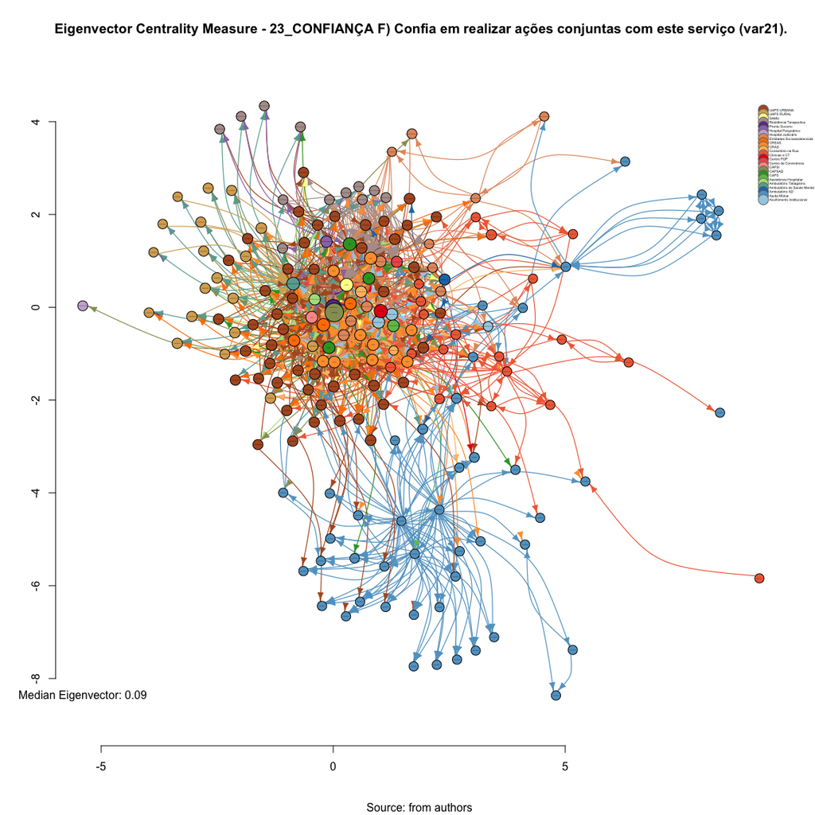

```r
set.seed(123)
#Plotting based only on eigenvector measures
edge.start <- ends(var21, es=E(var21), names=F)[,1]

# Fixing ego
minC <- rep(-Inf, vcount(var21))
maxC <- rep(Inf, vcount(var21))
minC[1] <- maxC[1] <- 0
co <- layout_with_fr(var21, niter=100000, minx=minC, maxx=maxC,miny=minC, maxy=maxC, weights = E(var21)$weight)

#Plotting
plot(var21,
     layout=co,
     edge.color=V(var21)$color[edge.start],
     edge.arrow.size=(eigen_centrality(var21, directed =TRUE, weights = E(var21)$weight)$vector),
     edge.width=E(var21)$weight/mean(E(var21)$weight),
     edge.curved = TRUE,
     vertex.color=V(var21)$color,
     vertex.size=(eigen_centrality(var21, directed =TRUE, weights = E(var21)$weight)$vector+1)*20,
     vertex.frame.color="black",
     vertex.label.color="black",
     vertex.label=get.vertex.attribute(var21,"LABEL_COR"),
     vertex.label.cex=sqrt((eigen_centrality(var21)$vector)+1)/10,
     vertex.label.dist=0,
     rescale=F,
     xlim=range(co[,1]),
     ylim=range(co[,2])
     )
axis(1)
axis(2)


#Solving Problems with legend rendering
a<-V(var21)$LABEL_COR
b<-V(var21)$color
c<-table(a,b)
d<-as.data.frame(c)
e<-subset(d, d$Freq>0)
e<-e[order(e$a,decreasing=T),]
f<-t(e$a)
g<-t(e$b)

#Adding Legend
legend(x=range(co[,1])[2],
       y=range(co[,2])[2],
       legend=as.character(f),
       pch=21,
       col = "#777777",
       pt.bg=as.character(g),
       pt.cex=2,
       bty="n",
       ncol=1,
       lty=1,
       cex = .3)

#Adding Title
    title("Eigenvector Centrality Measure - 23_CONFIANÇA F) Confia em realizar ações conjuntas com este serviço (var21).", sub = "Source: from authors ")
  text(
    x=range(co[,1])[1],
    y=range(co[,2])[1],
      labels =
      sprintf("Median Eigenvector: %.2f",
      median(eigen_centrality(var21)$vector)
             )
       )
```

# 9 Network Plotting Based On Centralization Eigenvector

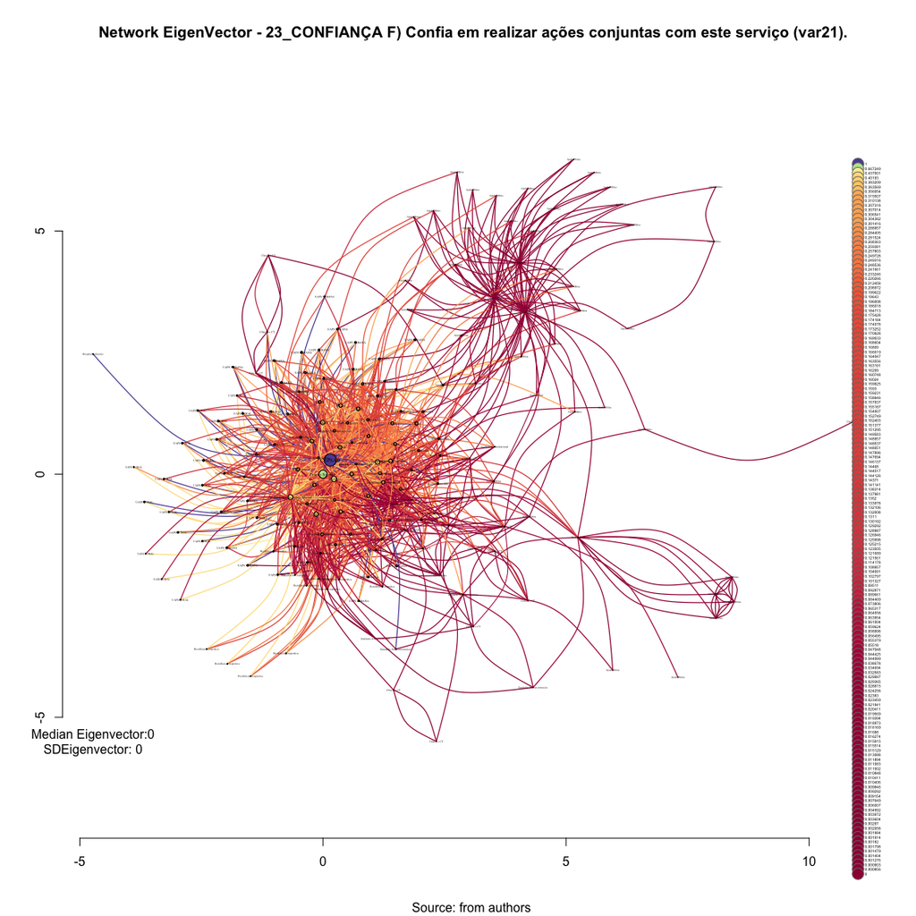

```r
set.seed(123)

#Get Variable
V(var21)$var21_color_degree<-round(centr_eigen(var21, directed = T)$vector,6)

#Creating brewer pallette
vertex_var21_color_degree<-
  colorRampPalette(brewer.pal(length(unique(
          V(var21)$var21_color_degree)), "Spectral"))(
            length(unique(V(var21)$var21_color_degree)))

#Saving as Vertex properties
V(var21)$vertex_var21_color_degree<-
  vertex_var21_color_degree[as.numeric(
  cut(V(var21)$var21_color_degree,
      breaks=length(unique(V(var21)$var21_color_degree))))]

set.seed(123)
#Plotting based only on degree measures
edge.start <- ends(var21, es=E(var21), names=F)[,1]

# Fixing ego
minC <- rep(-Inf, vcount(var21))
maxC <- rep(Inf, vcount(var21))
minC[1] <- maxC[1] <- 0
co <- layout_with_fr(var21, niter=10000, minx=minC, maxx=maxC,miny=minC, maxy=maxC, weights = E(var21)$weight)

#PLotting
plot(var21,
     layout=co,
     edge.color=V(var21)$vertex_var21_color_degree[edge.start],
     edge.arrow.size=closeness(var21, weights = E(var21)$var21, mode="in"),
     edge.width=E(var21)$weight/mean(E(var21)$weight),
     edge.curved = TRUE,
     vertex.color=V(var21)$vertex_var21_color_degree,
     vertex.size=(centr_eigen(var21, directed = T)$vector)*25,
     vertex.frame.color="black",
     vertex.label.color="black",
     vertex.label=get.vertex.attribute(var21,"LABEL_COR"),
     vertex.label.cex=(centr_eigen(var21, directed = T)$vector + 1)/5,
     vertex.label.dist=0,
     rescale=F,
     xlim=range(co[,1]),
     ylim=range(co[,2])
     )
axis(1)
axis(2)


#Solving Problems with legend rendering
a<-V(var21)$var21_color_degree
b<-V(var21)$vertex_var21_color_degree
c<-table(a,b)
d<-as.data.frame(c)
e<-subset(d, d$Freq>0)
e<-e[order(e$a,decreasing=T),]
f<-t(e$a)
g<-t(e$b)

#Adding Legend
legend(x=range(co[,1])[2],
       y=range(co[,2])[2],
       legend=as.character(f),
       pch=21,
       col = "#777777",
       pt.bg=as.character(g),
       pt.cex=2,
       bty="n",
       ncol=1,
       lty=1,
       cex = .3)

#Adding Title
  title("Network EigenVector - 23_CONFIANÇA F) Confia em realizar ações conjuntas com este serviço (var21).", sub = "Source: from authors ")
  text(
    x=range(co[,1])[1],
    y=range(co[,2])[1],
      labels =
      sprintf("Median Eigenvector:%.0f\nSDEigenvector: %.0f",
      mean(centr_eigen(var21, directed = T)$vector),
      sd(centr_eigen(var21, directed = T)$vector)
             )
       )
```

# 10 Saving objects with new variables and changes

```r
save.image("~/SNArRDJF/Robject/var21_data.RData")
```